# 01-BFALgtseq_test1-exploration

13 December 2022

Checking on the first GTseq run with the BFAL loci… which ones to keep; which ones to toss; how common is the NNNN problem?

```r
library(tidyverse)
```

```r
data <- read_csv("../data/BFAL_trimmed_observed_unfiltered_haplotype.csv") %>%
  select(-X1)
```

There are only 75 loci that appear in that dataset. There should be ~350.

```r
data %>%
  group_by(locus) %>%
  summarise(sum(depth))
```

| locus | sum(depth) |
| --- | --- |
| scaffold_0_4543438_PCR_Product | 280 |
| scaffold_110_1607315_PCR_Product | 139 |
| scaffold_111_413509_PCR_Product | 50 |
| scaffold_1164_119437_PCR_Product | 30 |
| scaffold_1226_116065_PCR_Product | 50405 |
| scaffold_1327_103421_PCR_Product | 148 |
| scaffold_138_809192_PCR_Product | 6920 |
| scaffold_143_1756997_PCR_Product | 13 |
| scaffold_146_16700_PCR_Product | 63 |
| scaffold_148_727111_PCR_Product | 162 |

[output cut: 65 more lines]

Many (most!) entries have only a single read!

A few general assessments: 1) total depth

```r
data %>%
  summarise(total_depth = sum(depth))
```

| total_depth |
| --- |
| 645375 |

2. depth across loci

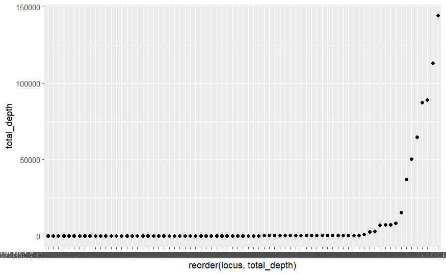

```r
data %>%
  group_by(locus) %>%
  summarise(total_depth = sum(depth)) %>%
  arrange(desc(total_depth)) %>%
  ggplot(aes(x = reorder(locus, total_depth), y = total_depth)) +
  geom_point()
```

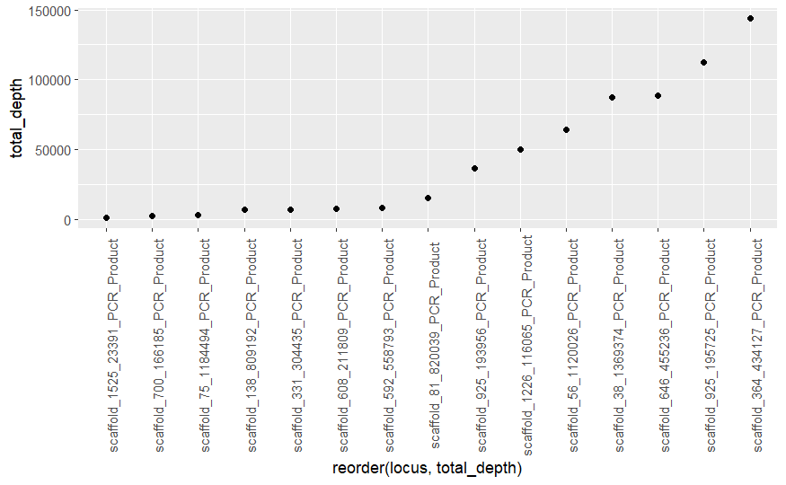

```r
data %>%
  group_by(locus) %>%
  summarise(total_depth = sum(depth)) %>%
  arrange(desc(total_depth)) %>%
  filter(total_depth > 1000) %>%
  ggplot(aes(x = reorder(locus, total_depth), y = total_depth)) +
  geom_point() +
  theme(
    axis.text.x = element_text(angle = 90)
  )
```

scaffold_364_434127 scaffold_925_195725

What about reads across indivs

```r
data %>%
  group_by(indiv.ID) %>%
  summarise(total_depth = sum(depth)) %>%
  arrange(desc(total_depth))
```

| indiv.ID | total_depth |
| --- | --- |
| s468 | 12720 |
| s473 | 12512 |
| s475 | 12411 |
| s451 | 12363 |
| s465 | 11960 |
| s436 | 11817 |
| s457 | 11377 |
| s458 | 11319 |
| s467 | 11167 |
| s477 | 10997 |

[output cut: 83 more lines]

```r
NA
NA
```

Make a heatmap of reads/locus/indiv

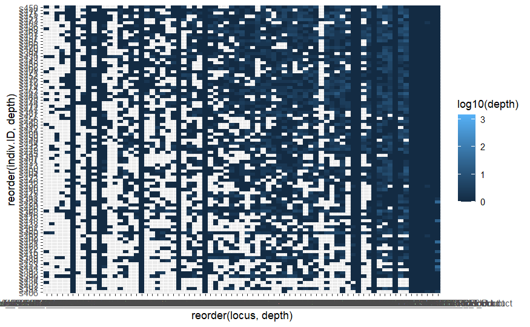

```r
data %>%
  ggplot(aes(x = reorder(locus, depth), y = reorder(indiv.ID, depth), fill = log10(depth))) +
  geom_tile()
```

What if I remove the top loci?

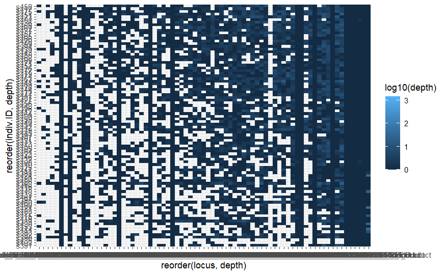

```r
data %>%
  filter(!locus %in% c("scaffold_364_434127","scaffold_925_195725") &
           !indiv.ID %in% c("s406", "s434", "s402")) %>%
  ggplot(aes(x = reorder(locus, depth), y = reorder(indiv.ID, depth), fill = log10(depth))) +
  geom_tile()
```

Loci…

How many actual haplotypes with N base-calls?

```r
reads_w_Ns <- data %>%
  filter(!locus %in% c("scaffold_364_434127","scaffold_925_195725") &
   !indiv.ID %in% c("s406", "s434", "s402"),
    str_detect(haplo, "N"),
   depth > 10)

# unique haplotypes with Ns by locus
reads_w_Ns %>%
  select(locus, haplo) %>%
  unique() %>%
  group_by(locus) %>%
  tally() %>%
  arrange(desc(n))
```

| locus | n |
| --- | --- |
| scaffold_646_455236_PCR_Product | 37 |
| scaffold_81_820039_PCR_Product | 2 |
| scaffold_1525_23391_PCR_Product | 1 |
| scaffold_592_558793_PCR_Product | 1 |

```r
NA
```

We dealt with the N issue by trimming the fasta file (so that there wasn’t flanking sequence).

Which loci have only haplotypes with Ns?

```r
N_haplos <- data %>%
  mutate(Ns = ifelse(str_detect(haplo, "N"), 1, 0)) %>%
   filter(!locus %in% c("scaffold_364_434127","scaffold_925_195725") &
   !indiv.ID %in% c("s406", "s434", "s402"),
   depth > 2) %>%
  select(locus, haplo, Ns) %>%
  unique() %>%
  group_by(locus) %>%
  mutate(n_haplo = sum(Ns)) %>%
  select(locus, n_haplo) %>%
  unique() # this is the number of haplotypes with Ns by locus
```

But to get the ratio, I need additional data.

```r
# total number of haplotypes per locus
haplo_per_loc <- data %>%
  mutate(Ns = ifelse(str_detect(haplo, "N"), 1, 0)) %>%
   filter(!locus %in% c("scaffold_364_434127","scaffold_925_195725") &
   !indiv.ID %in% c("s406", "s434", "s402"),
   depth > 2) %>%
  select(locus, haplo) %>%
  unique() %>%
  group_by(locus) %>%
  tally()
```

Combine those two things:

```r
N_haplos %>%
  left_join(., haplo_per_loc) %>%
  mutate(N_ratio = n_haplo/n) %>%
  filter(N_ratio < 0.5)
```

| locus | n_haplo | n | N_ratio |
| --- | --- | --- | --- |
| scaffold_1226_116065_PCR_Product | 1 | 16 | 0.062500000 |
| scaffold_925_195725_PCR_Product | 11 | 482 | 0.022821577 |
| scaffold_38_1369374_PCR_Product | 1 | 166 | 0.006024096 |
| scaffold_364_434127_PCR_Product | 1 | 176 | 0.005681818 |
| scaffold_56_1120026_PCR_Product | 1 | 466 | 0.002145923 |
| scaffold_592_558793_PCR_Product | 1 | 13 | 0.076923077 |
| scaffold_925_193956_PCR_Product | 1 | 137 | 0.007299270 |
| scaffold_608_211809_PCR_Product | 5 | 41 | 0.121951220 |
| scaffold_81_820039_PCR_Product | 55 | 193 | 0.284974093 |
| scaffold_1525_23391_PCR_Product | 2 | 7 | 0.285714286 |

[output cut: 58 more lines]

I don’t love it, but I’m going to move forward and modify the primer concentrations for the next test run.

NOTE: didn’t do this.

Modify primer concentrations for round 2.

```r
primers_test2 <- data %>%
  group_by(locus) %>%
  summarise(total_depth = sum(depth)) %>%
  arrange(desc(total_depth)) %>%
  mutate(action = ifelse(total_depth > 200000, 0, 1)) %>%
  mutate(action = ifelse(total_depth > 100 & total_depth < 1000, 1, action)) %>%
  mutate(action = ifelse(total_depth < 100 & total_depth > 10, 1.5, action)) %>%
  mutate(action = ifelse(total_depth > 1000 & total_depth < 200000, 0.5, action)) %>%
  mutate(action = ifelse(total_depth < 10, 1.75, action)) %>%
  # add in the original primer concentration
  mutate(primer_conc = 0.25, new_conc = action*primer_conc, stock_conc = 100, pool_vol = 1000, cherrypick_vol = (new_conc*pool_vol)/stock_conc) %>%
  # now split the pool into 2 based on read depth
  mutate(primer_pool = ifelse(total_depth > 200, "Pool1", "Pool2")) %>%
  group_by(primer_pool) %>%
  add_tally() #%>%
  #write_csv("../outputs/BFALgtseq_test2_primer_pool.csv")
```

### Primer pool for round 2

Read in the overampers file from the `microhaplot_local.R` script.

```r
overampers <- read_csv("../results/test1_overampers.csv")
# fix the formatting
overampers1 <- gsub("_PCR_Product", "", overampers$locus)

overampers$locus <- overampers1

overampers
```

| locus | reads |
| --- | --- |
| scaffold_364_434127 | 232945 |
| scaffold_646_455236 | 231560 |
| scaffold_925_195725 | 113535 |
| scaffold_38_1369374 | 87364 |
| scaffold_56_1120026 | 64582 |
| scaffold_138_809192 | 54867 |
| scaffold_1226_116065 | 50405 |
| scaffold_925_193956 | 36857 |
| scaffold_81_820039 | 15340 |

One more thing needed for the cherrypick file: in which well is each primer located?

```r
# read in primer plate map
platemap <- readxl::read_xlsx("../IDTplateSpecs_BFALgtseq_20221012.xlsx")
```

```r
# select the relevant variables and make the sequence name match the data
platemap1 <- platemap %>%
  select(`Plate Name`, `Well Position`, `Sequence Name`) %>%
  rename(locus = `Sequence Name`)


tmp <- gsub("BFAL_", "", platemap1$locus)
tmp1 <- gsub("_R", "", tmp)
tmp2 <- gsub("_F", "", tmp1)

platemap1$locus <- tmp2

platemap1
```

| Plate Name | Well Position | locus |
| --- | --- | --- |
| BFALgtseqPlate4R | A01 | scaffold_608_211809 |
| BFALgtseqPlate4R | A02 | scaffold_690_230050 |
| BFALgtseqPlate4R | A03 | scaffold_725_81958 |
| BFALgtseqPlate4R | A04 | scaffold_793_76520 |
| BFALgtseqPlate4R | A05 | scaffold_876_284721 |
| BFALgtseqPlate4R | A06 | scaffold_1050_36334 |
| BFALgtseqPlate4R | A07 | scaffold_1226_116065 |
| BFALgtseqPlate4R | B01 | scaffold_612_363793 |
| BFALgtseqPlate4R | B02 | scaffold_690_26744 |
| BFALgtseqPlate4R | B03 | scaffold_738_79656 |

[output cut: 678 more lines]

```r
# merge those two things:
# platemap1 %>%
#   left_join(., primers_test2) %>%
#   write_csv("../outputs/BFALgtseq_test2_primer_pool.csv")

overampers %>%
  left_join(., platemap1) %>%
  write_csv("../outputs/BFALgtseq_test2_primer_to_remove.csv")
```

## Taking a look at output from GTscore

The plot we want is the R1 reads where the FWD primer was found vs. the flashed read where the FWD primer was found.

```r
# read in the GTscore output

flashed <- read_tsv("../data/flashed_GTscore_locusSummary.txt") %>%
  select(Locus, `Primer Reads`) %>%
  rename(flashed_reads = `Primer Reads`)
R1 <- read_tsv("../data/R1_GTscore_locusSummary.txt") %>%
  select(Locus, `Primer Reads`) %>%
  rename(R1_reads = `Primer Reads`)
```

Look at those two df combined based on locus

```r
combo_df <- R1 %>%
  left_join(., flashed, by = "Locus")

combo_df %>%
  summarise(sum(R1_reads))
```

| sum(R1_reads) |
| --- |
| 2659910 |

```r
combo_df %>%
  summarise(sum(flashed_reads))
```

| sum(flashed_reads) |
| --- |
| 675775 |

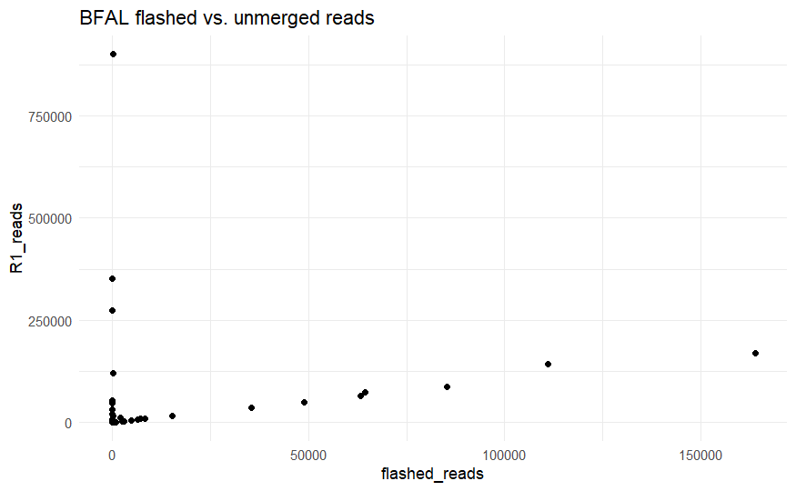

```r
combo_df %>%
  ggplot(aes(x = flashed_reads, y = R1_reads)) +
  geom_point() +
  labs(title = "BFAL flashed vs. unmerged reads") +
  theme_minimal()

ggsave("pdf_outputs/BFAL_gtseq_test1_offtarget.pdf")
```

So the loci that would be concerning are those with high numbers for the unmerged (R1) reads and disproportionately low numbers for the flashed reads in comparison.

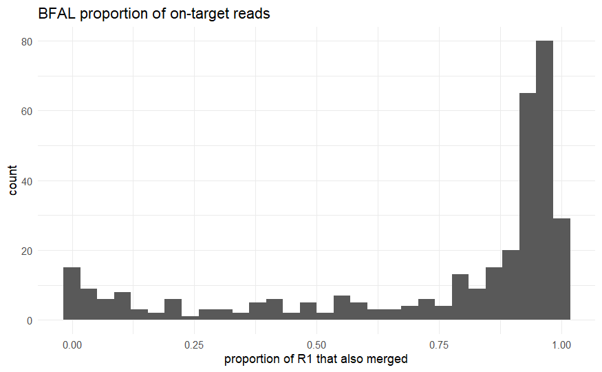

Look at the loci with < 50% on-target (because read depths were low for this run, I’m not necessarily going to drop these)

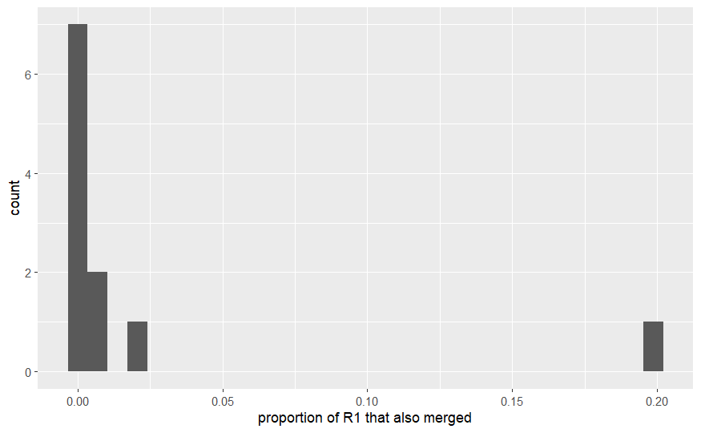

```r
combo_df %>%
  mutate(prop = flashed_reads/R1_reads) %>%
  filter(prop < 0.5,
         R1_reads > 10000) %>%
  ggplot(aes(x = prop)) +
  geom_histogram() +
  labs(x = "proportion of R1 that also merged")
```

```r
NA
NA
```

For these loci, I think I’m only concerned if there were legitimately a lot of reads in the R1 reads. Otherwise, it’s probably just an issue of low depth.

Seems like I could easily draw the line at 0.05.

| Locus | R1_reads | flashed_reads | prop |
| --- | --- | --- | --- |
| BFAL_scaffold_10_3765633 | 17002 | 362 | 2.129161e-02 |
| BFAL_scaffold_100_1137898 | 274294 | 69 | 2.515549e-04 |
| BFAL_scaffold_105_200086 | 54182 | 4 | 7.382526e-05 |
| BFAL_scaffold_183_1635348 | 121316 | 189 | 1.557915e-03 |
| BFAL_scaffold_234_1154895 | 47058 | 40 | 8.500149e-04 |
| BFAL_scaffold_438_594545 | 20315 | 92 | 4.528673e-03 |
| BFAL_scaffold_554_435715 | 900937 | 183 | 2.031219e-04 |
| BFAL_scaffold_645_141602 | 352408 | 139 | 3.944292e-04 |
| BFAL_scaffold_698_181961 | 32560 | 67 | 2.057740e-03 |
| BFAL_scaffold_876_284721 | 20573 | 138 | 6.707821e-03 |

10 loci to potentially drop.

Are these distinct from the loci to remove based on the idx stats?

| locus | reads | drop | R1_reads | flashed_reads | prop |
| --- | --- | --- | --- | --- | --- |
| scaffold_10_3765633 | NA | off-target | 17002 | 362 | 2.129161e-02 |
| scaffold_100_1137898 | NA | off-target | 274294 | 69 | 2.515549e-04 |
| scaffold_105_200086 | NA | off-target | 54182 | 4 | 7.382526e-05 |
| scaffold_1226_116065 | 50405 | overamper | NA | NA | NA |
| scaffold_138_809192 | 54867 | overamper | NA | NA | NA |
| scaffold_183_1635348 | NA | off-target | 121316 | 189 | 1.557915e-03 |
| scaffold_234_1154895 | NA | off-target | 47058 | 40 | 8.500149e-04 |
| scaffold_364_434127 | 232945 | overamper | NA | NA | NA |
| scaffold_38_1369374 | 87364 | overamper | NA | NA | NA |
| scaffold_438_594545 | NA | off-target | 20315 | 92 | 4.528673e-03 |

[output cut: 9 more lines]

```r
locs_to_lose %>%
  left_join(., platemap1) %>%
  select(locus, drop, `Plate Name`, `Well Position`) %>%
  write_csv("../outputs/BFAL_primers_to_remove_20230104.csv")
```